# Bioc2021: Visualisation of highly-multiplexed imaging data in R

Nils Eling, Nicolas Damond, Tobias Hoch and Bernd Bodenmiller

Department for Quantitative Biomedicine, University of Zurich  
Institute for Molecular Health Sciences, ETH Zurich

nils.eling@dqbm.uzh.ch

22 July 2021

#### Abstract

Highly multiplexed imaging cytometry acquires the single-cell expression of selected proteins in a spatially-resolved fashion. These measurements can be visualized across multiple length-scales. First, pixel-level intensities represent the spatial distributions of feature expression with highest resolution. Second, after segmentation, expression values or cell-level metadata (e.g. cell-type information) can be visualized on segmented cell areas. This package contains functions for the visualization of multiplexed read-outs and cell-level information obtained by multiplexed imaging cytometry. The main functions of this package allow 1. the visualization of pixel-level information across multiple channels and 2. the display of cell-level information (expression and/or metadata) on segmentation masks.

#### Package

cytomapper 1.4.1

# 1 Data and code availability

To follow this tutorial, please visit https://github.com/BodenmillerGroup/cytomapper_demos/docs. The compiled .html of this workshop is hosted at: https://bodenmillergroup.github.io/cytomapper_demos. The [cytomapper](https://www.bioconductor.org/packages/release/bioc/html/cytomapper.html) package can be installed via:

```r
if (!requireNamespace("BiocManager", quietly = TRUE))
    install.packages("BiocManager")

BiocManager::install("cytomapper")
```

To reproduce the analysis, clone the repository:

```
git clone https://github.com/BodenmillerGroup/cytomapper_demos.git
```

and open the `Bioc2021_workshop.Rmd` file in the `docs` folder.

We provide three images, their segmentation masks and the quantified single-cell data in form of a `SingleCellExperiment` object in the `data` folder. The data is taken from [A map of human type 1 diabetes progression by imaging mass cytometry](https://www.sciencedirect.com/science/article/pii/S1550413118306910).

# 2 Introduction

The analysis and visualization of highly-multiplexed imaging data relies on three types of data structures:

- Multi-channel images realized as three dimensional arrays where the numeric entry of each voxel represents the intensity of the pixel at position `x` and `y` for channel `c`.
- Single-channel segmentation masks realized as matrices where sets of pixels with the same integer ID represent individual objects (here, these are segmented cells)
- A table containing the quantified features per cell and channel (e.g. mean pixel intensity)

The `cytomapper` package handles these data types using objects of the following S4 classes:

- Multiple multi-channel images are stored in form of `EBImage::Image` objects within a `cytomapper::CytoImageList` object
- Multiple single-channel segmentation masks are stored in form of `EBImage::Image` objects within a `cytomapper::CytoImageList` object
- Per-cell intensity measures and cell-/channel-specific metadata are stored in a `SingleCellExperiment::SingleCellExperiment` container

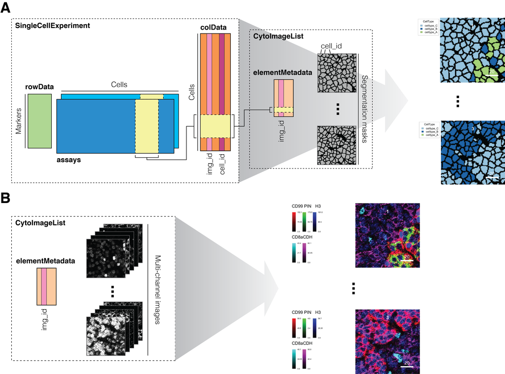

cytomapper overview figure. A) The plotCells function combines a SingleCellExperiment and CytoImageList object to visualize marker expression or cell-specific metadata on segmentation masks. B) The plotPixels function requires a CytoImageList object to visualize the combined expression of up to six markers as composite images

The `cytomapper` package contains three broad functionalities:

- Visualization of pixel-intensities as composites of up to six channels (`plotPixels`)
- Visualization of cell-specific features on segmentation masks (`plotCells`)
- Interactive gating of cells and visualization of gated cells on images (`cytomapperShiny`)

We use [imaging mass cytometry](https://www.nature.com/articles/nmeth.2869) data to highlight the functionality of the `cytomapper` package. However, any imaging technology is supported as long as the data can be read into R (memory restrictions and file type restrictions.)

The raw data has been processed using the ImcSegmentationPipeline. In this tutorial, we assume that image segmentation has been performed beforehand.

# 3 Reading in the data

The following section describes how to read in images (e.g. in `.tiff` format) into `CytoImageList` objects and how to generate `SingleCellExperiment` objects from these images.

## 3.1 Reading in images

The `cytomapper::loadImages` function reads in multi-channel images and segmentation masks into `CytoImageList` objects.

```r
library(cytomapper)

# Read in 32-bit multi-channel images
(images <- loadImages("../data/images/", pattern = ".tiff"))
```

```
## CytoImageList containing 3 image(s)
## names(3): E30_a0_full_clean G23_a0_full_clean J01_a0_full_clean
## Each image contains 38 channel(s)
```

```r
# Read in 16-bit unsigned integer segmentation masks
(masks <- loadImages("../data/masks/", pattern = ".tiff"))
```

```
## CytoImageList containing 3 image(s)
## names(3): E30_a0_full_mask G23_a0_full_mask J01_a0_full_mask
## Each image contains 1 channel
```

It is always recommended to observe the numeric pixel values to make sure that images were read in correctly:

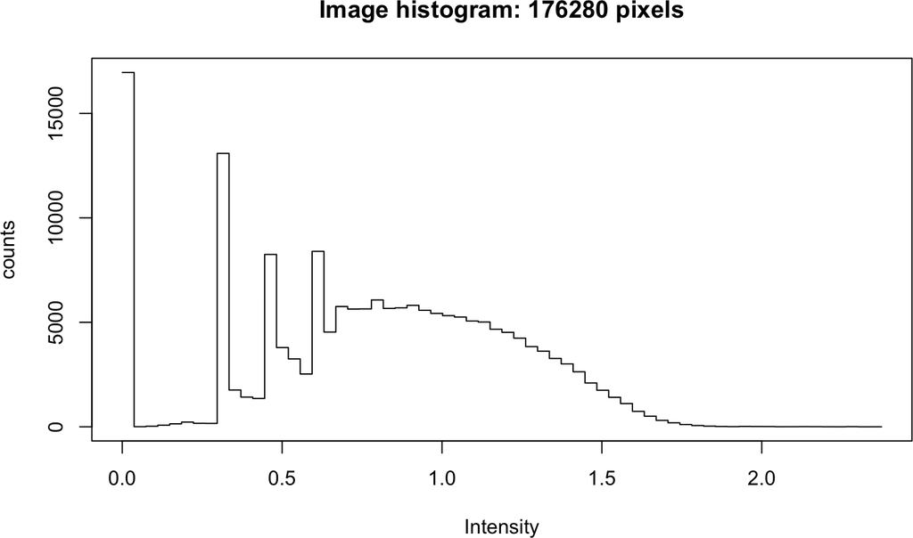

```r
# multi-channel images - first image, first channel
hist(log10(images[[1]][,,1] + 1))
```

```r
# Segmentation mask
masks[[1]]
```

```
## Image
##   colorMode    : Grayscale
##   storage.mode : double
##   dim          : 390 452
##   frames.total : 1
##   frames.render: 1
##
## imageData(object)[1:5,1:6]
##              [,1]         [,2]         [,3]         [,4]         [,5]
## [1,] 0.000000e+00 0.000000e+00 0.000000e+00 0.000000e+00 4.577707e-05
## [2,] 0.000000e+00 0.000000e+00 0.000000e+00 0.000000e+00 4.577707e-05
## [3,] 4.577707e-05 4.577707e-05 4.577707e-05 4.577707e-05 4.577707e-05
## [4,] 4.577707e-05 4.577707e-05 4.577707e-05 4.577707e-05 4.577707e-05
## [5,] 4.577707e-05 4.577707e-05 4.577707e-05 4.577707e-05 4.577707e-05
##              [,6]
## [1,] 0.000000e+00
## [2,] 0.000000e+00
## [3,] 4.577707e-05
## [4,] 4.577707e-05
## [5,] 4.577707e-05
```

We notice, that the segmentation masks were not read in as integer images. This behavior arises due to issues with accessing the `tiff` metadata after pre-processing using `CellProfiler`.

In these cases, the `cytomapper::scaleImages` function can be used to rescale segmentation masks to only contain interger IDs. Here, the scaling factor is `2 ^ 16 - 1 = 65535` accounting for the 16-bit unsigned integer encoding.

```r
masks <- scaleImages(masks, 2 ^ 16 - 1)

masks[[1]]
```

```
## Image
##   colorMode    : Grayscale
##   storage.mode : double
##   dim          : 390 452
##   frames.total : 1
##   frames.render: 1
##
## imageData(object)[1:5,1:6]
##      [,1] [,2] [,3] [,4] [,5] [,6]
## [1,]    0    0    0    0    3    0
## [2,]    0    0    0    0    3    0
## [3,]    3    3    3    3    3    3
## [4,]    3    3    3    3    3    3
## [5,]    3    3    3    3    3    3
```

As an alternative, while reading in the images, the `as.is` option can be set to `TRUE`.

```r
masks <- loadImages("../data/masks/", pattern = ".tiff", as.is = TRUE)

masks[[1]]
```

```
## Image
##   colorMode    : Grayscale
##   storage.mode : integer
##   dim          : 390 452
##   frames.total : 1
##   frames.render: 1
##
## imageData(object)[1:5,1:6]
##      [,1] [,2] [,3] [,4] [,5] [,6]
## [1,]    0    0    0    0    3    0
## [2,]    0    0    0    0    3    0
## [3,]    3    3    3    3    3    3
## [4,]    3    3    3    3    3    3
## [5,]    3    3    3    3    3    3
```

We can already visualize the segmentation mask to get an idea of the tissue structure:

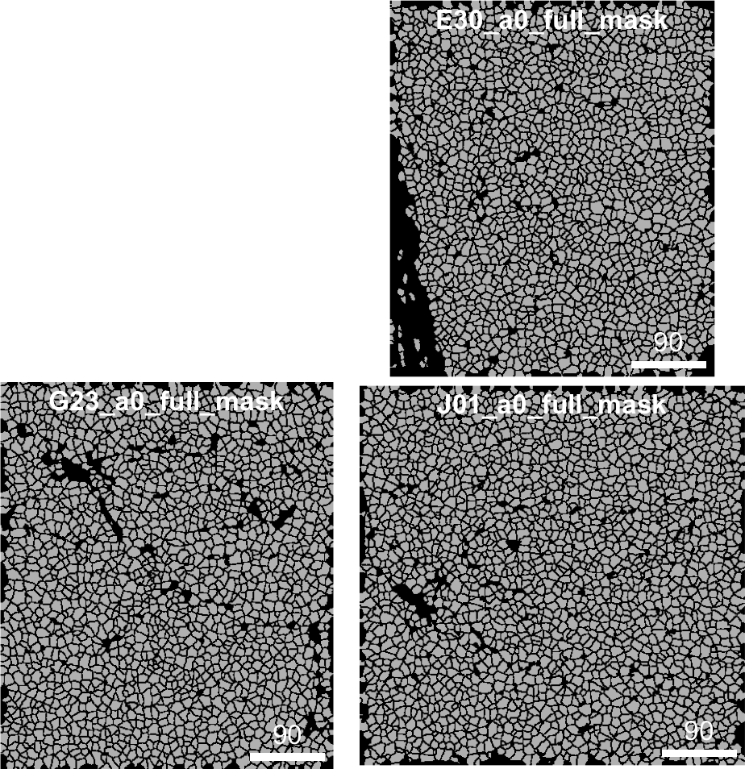

```r
plotCells(masks)
```

### 3.1.1 Reading data to disk

To increase scalability of the `cytomapper` package, images can be stored on disk making use of the `HDF5Array` and `DelayedArray` package. Reading in the data can also be parallelised, which is only recommended for large images.

```r
format(object.size(images), units = "Kb")
```

```
## [1] "170235.4 Kb"
```

```r
images_ondisk <- loadImages("../data/images/", pattern = ".tiff",
                            on_disk = TRUE, h5FilesPath = "../data/images",
                            BPPARAM = BiocParallel::bpparam())

format(object.size(images_ondisk), units = "Kb")
```

```
## [1] "10.1 Kb"
```

All `cytomapper` functions support images and masks stored on disk.

## 3.2 The `SingleCellExperiment` object

In the original analysis, single-cell features have been extracted using `CellProfiler`. For this tutorial, we provide a `SingleCellExperiment` object, which already contains the mean intensities per cell and channel and all relevant metadata (e.g. cell-type annotation).

The `SingleCellExperiment` can be read-in form the `data` folder:

```r
(sce <- readRDS("../data/sce.rds"))
```

```
## class: SingleCellExperiment
## dim: 38 5819
## metadata(0):
## assays(2): counts exprs
## rownames(38): H3 SMA ... Ir191 Ir193
## rowData names(15): TubeNb MetalTag ... miCAT2 miCAT
## colnames(5819): E30_1 E30_2 ... J01_2173 J01_2174
## colData names(26): slide id ... Ethnicity BMI
## reducedDimNames(0):
## mainExpName: NULL
## altExpNames(0):
```

```r
colData(sce)
```

```
## DataFrame with 5819 rows and 26 columns
##                slide          id ImageNumber CellNumber     Pos_X     Pos_Y
##          <character> <character>   <integer>  <integer> <numeric> <numeric>
## E30_1              E       E30_1         166          1   171.375   0.62500
## E30_2              E       E30_2         166          2   149.400   1.60000
## E30_3              E       E30_3         166          3     6.400   3.36471
## E30_4              E       E30_4         166          4   220.756   2.85366
## E30_5              E       E30_5         166          5   189.523   4.95455
## ...              ...         ...         ...        ...       ...       ...
## J01_2170           J    J01_2170         286       2170   435.950   453.050
## J01_2171           J    J01_2171         286       2171   456.469   452.688
## J01_2172           J    J01_2172         286       2172   340.643   453.643
## J01_2173           J    J01_2173         286       2173    19.900   454.500
## J01_2174           J    J01_2174         286       2174    43.250   454.625
##          ParentIslet ClosestIslet      Area NbNeighbours          ImageFullName
##            <integer>    <integer> <integer>    <integer>            <character>
## E30_1              0            1         8            2 E30_a0_full_clean.tiff
## E30_2              0            1         5            2 E30_a0_full_clean.tiff
## E30_3              0            1        85            3 E30_a0_full_clean.tiff
## E30_4              0            1        41            4 E30_a0_full_clean.tiff
## E30_5              0            1        44            5 E30_a0_full_clean.tiff
## ...              ...          ...       ...          ...                    ...
## J01_2170           0            1        40            4 J01_a0_full_clean.tiff
## J01_2171           0            1        64            3 J01_a0_full_clean.tiff
## J01_2172           0            1        42            3 J01_a0_full_clean.tiff
## J01_2173           0            1        10            3 J01_a0_full_clean.tiff
## J01_2174           0            1        16            2 J01_a0_full_clean.tiff
##              width    height   ImageName     CellCat    CellType      case
##          <integer> <integer> <character> <character> <character> <integer>
## E30_1          390       452         E30    exocrine      ductal      6126
## E30_2          390       452         E30      immune  macrophage      6126
## E30_3          390       452         E30    exocrine      acinar      6126
## E30_4          390       452         E30    exocrine      acinar      6126
## E30_5          390       452         E30    exocrine      ductal      6126
## ...            ...       ...         ...         ...         ...       ...
## J01_2170       463       456         J01    exocrine      ductal      6180
## J01_2171       463       456         J01    exocrine      acinar      6180
## J01_2172       463       456         J01    exocrine      acinar      6180
## J01_2173       463       456         J01    exocrine      acinar      6180
## J01_2174       463       456         J01    exocrine      acinar      6180
```

[output cut: 11 more lines]

```
## J01_2173        Tail         2 Long-duration        11    Positive        27
## J01_2174        Tail         2 Long-duration        11    Positive        27
##               Gender   Ethnicity       BMI
##          <character> <character> <numeric>
## E30_1              M   Caucasian      25.1
## E30_2              M   Caucasian      25.1
## E30_3              M   Caucasian      25.1
## E30_4              M   Caucasian      25.1
## E30_5              M   Caucasian      25.1
## ...              ...         ...       ...
## J01_2170           M   Caucasian      25.9
## J01_2171           M   Caucasian      25.9
## J01_2172           M   Caucasian      25.9
## J01_2173           M   Caucasian      25.9
## J01_2174           M   Caucasian      25.9
```

# 4 Image pre-processing

The following section will discuss setting image metadata and image normalization.

## 4.1 Setting metadata

Before image visualization, there are a few metadata that need to be set.

We will need to set the channel names of the images via the `channelNames` getter/setter function. The channel order here is the same as the row order of the `SingleCellExperiment` object. We will also need to synchronise the image IDs across the multi-channel images and segmentation masks by storing a DataFrame in the elementMetadata slot of the CytoImageList object.

```r
# Add channel names
channelNames(images) <- rownames(sce)

# Add image name to metadata
(mcols(images) <- mcols(masks) <- DataFrame(ImageName = c("E30", "G23", "J01")))
```

```
## DataFrame with 3 rows and 1 column
##     ImageName
##   <character>
## 1         E30
## 2         G23
## 3         J01
```

## 4.2 Normalization

Channel normalization is a crucial step for image visualization to enhance the visibility of biological signals. One option is to transform (e.g. `sqrt`) transform the images. A more widely used alternative is to perform a range-scaling and clipping of channel intensities.

The `cytomapper` package exports the `normalize` function that scales channels between 0 and 1 across all images (by default). Clipping is performed by setting the `inputRange` parameter in the `normalize` function.

```r
# Min-max normalization
images_norm <- normalize(images)

# Clip the images
images_norm <- normalize(images_norm, inputRange = c(0, 0.2))
```

## 4.3 Measuring object features

The `cytomapper::measureObjects` function takes the segmentation masks and multi- channel image objects and computes morphological (e.g. cell shape, size and location) and intensity features (default: mean intensity per channel and object/cell).

```r
sce_measured <- measureObjects(mask = masks, image = images, img_id = "ImageName")
sce_measured
```

```
## class: SingleCellExperiment
## dim: 38 5819
## metadata(0):
## assays(1): counts
## rownames(38): H3 SMA ... Ir191 Ir193
## rowData names(0):
## colnames: NULL
## colData names(8): ImageName object_id ... m.majoraxis m.eccentricity
## reducedDimNames(0):
## mainExpName: NULL
## altExpNames(0):
```

The pixel intensities per cell can be summarized in different ways (e.g. as quantiles). Furthermore, parallelization is possible by setting `BPPARAM = bpparam()`. Cell-specific morphological features are stored in `colData(sce)` while the mean pixel intensities per cell and channel are stored in `counts(sce)`.

```r
colData(sce_measured)
```

```
## DataFrame with 5819 rows and 8 columns
##        ImageName object_id    s.area s.radius.mean      m.cx      m.cy
##      <character> <numeric> <numeric>     <numeric> <numeric> <numeric>
## 1            E30         1         8      1.132373   172.375   1.62500
## 2            E30         2         5      0.969029   150.400   2.60000
## 3            E30         3        85      4.928794     7.400   4.36471
## 4            E30         4        41      3.148247   221.756   3.85366
## 5            E30         5        44      3.454595   190.523   5.95455
## ...          ...       ...       ...           ...       ...       ...
## 5815         J01      2170        40       3.15461   436.950   454.050
## 5816         J01      2171        64       4.26023   457.469   453.688
## 5817         J01      2172        42       3.51294   341.643   454.643
## 5818         J01      2173        10       1.55575    20.900   455.500
## 5819         J01      2174        16       2.46488    44.250   455.625
##      m.majoraxis m.eccentricity
##        <numeric>      <numeric>
## 1        3.96961       0.713215
## 2        4.34170       0.955796
## 3       13.40271       0.767751
## 4        8.17150       0.515845
## 5       10.23176       0.792695
## ...          ...            ...
## 5815     8.85424       0.722069
## 5816    12.40952       0.812136
## 5817    12.96285       0.936558
## 5818     6.43099       0.928765
## 5819    10.74725       0.985845
```

```r
counts(sce_measured)[1:10, 1:10]
```

```
##              [,1]      [,2]        [,3]      [,4]        [,5]       [,6]
## H3     22.6329811 2.4361224 13.08346010 6.7423978 14.72265212 11.5127982
## SMA     0.7880026 1.0405174  1.26743278 0.9876558  0.32023911  0.7070429
## INS     0.0000000 0.0000000  0.24131852 0.2329416  0.16629238  0.2158641
## CD38    0.3090078 0.2992626  0.32912218 0.1752310  0.20383297  0.2546964
## CD44    2.3301406 0.4281695  0.59169109 0.4615597  1.78500872  0.4622892
## PCSK2   1.1045258 1.0593891  0.56905349 0.5634079  0.85554019  0.7053719
## CD99    0.3115875 0.3936061  0.77623081 1.0573374  0.89659225  0.9886102
## CD68    0.0000000 4.7920089  0.31981109 0.4370047  1.25933963  0.2232831
## MPO     0.0000000 5.1032834  0.07681261 0.1129901  0.04637183  0.1006678
## SLC2A1  2.8200562 2.2636643  0.79776477 1.4814364  1.74246915  0.4607339
##              [,7]      [,8]      [,9]      [,10]
## H3     6.65392760 8.7451991 6.6297040 9.66234309
## SMA    1.94122101 1.2825997 1.3894975 0.78360098
## INS    0.09161043 0.1462787 0.1709020 0.09961374
## CD38   0.26884190 0.5762133 0.3820182 0.50709601
## CD44   0.40098510 0.5384129 0.3380702 0.75498592
## PCSK2  0.65091868 0.8107124 1.0038303 0.68700536
## CD99   0.73302101 0.7973502 0.5520242 0.94204760
## CD68   1.04103449 0.7391340 0.2099665 1.36866162
## MPO    3.35050052 5.6631805 0.6724382 8.20452772
## SLC2A1 1.61920737 2.3110813 1.0785549 2.68912075
```

# 5 Data visualization

## 5.1 plotPixels

## 5.2 plotCells

## 5.3 outline Cells

# 6 Interactive visualization

# 7 Further resources

imcdatasets

imcRtools

steinbock

imcsegmentationpipeline